# second_notebook

```python
import pandas as pd
import numpy as np
```

Считаем файл `sku_dict.csv` и посмотрим на его первые 5 записей

```python
sku_dict = pd.read_csv('sku_dict.csv')
```

```python
sku_dict.head()
```

|  | sku_id | fincode | ui1_code | ui2_code | ui3_code | vendor | brand_code | creation_date | expiration_date |
| --- | --- | --- | --- | --- | --- | --- | --- | --- | --- |
| 0 | 43207 | A1 | A10 | A1000 | A1000001 | A10001 | A1000001 | 2018-01-01 | 2200-01-01 00:00:00 |
| 1 | 87209 | UA | UA1 | UA100 | UA10000 | BLW9FG | 484JDFU5 | 2019-09-05 | 2200-01-01 00:00:00 |
| 2 | 33513 | G9 | G91 | G9100 | G910003 | 7I77VL | MMC2P4Y3 | 2018-07-21 | 2200-01-01 00:00:00 |
| 3 | 47505 | AQ | AQ1 | AQ100 | AQ10000 | 4HJSP5 | 8FYENEWM | 2018-03-26 | 2200-01-01 00:00:00 |
| 4 | 53350 | 6L | 6L1 | 6L100 | 6L10005 | JSOSD5 | YTE7JS4H | 2018-11-30 | 2200-01-01 00:00:00 |

Заметим, что колонки `fincode`, `ui1_code`, `ui2_code` и `ui3_code` имеют схожие черты: следующая дополняет предыдущую. Аналогичная ситуация и с колонками `vendor` и `brand_code`

# EDA

Посмотрим, с какими данными мы имеем дело, какой их тип, сколько пропусков в данных

```python
sku_dict.info()
```

```
<class 'pandas.core.frame.DataFrame'>
RangeIndex: 10000 entries, 0 to 9999
Data columns (total 9 columns):
 #   Column           Non-Null Count  Dtype
---  ------           --------------  -----
 0   sku_id           10000 non-null  int64
 1   fincode          10000 non-null  object
 2   ui1_code         10000 non-null  object
 3   ui2_code         10000 non-null  object
 4   ui3_code         10000 non-null  object
 5   vendor           10000 non-null  object
 6   brand_code       10000 non-null  object
 7   creation_date    10000 non-null  object
 8   expiration_date  10000 non-null  object
dtypes: int64(1), object(8)
memory usage: 703.2+ KB
```

Видно,что у нас в датасете 10000 записей и что в данных нет пропусков

Посчитаем сколько в каждой из колоно уникальных записей:

```python
for col in sku_dict.columns:
    print(col,sku_dict['{}'.format(col)].nunique())
```

```
sku_id 10000
fincode 31
ui1_code 46
ui2_code 109
ui3_code 804
vendor 25
brand_code 63
creation_date 669
expiration_date 582
```

Видно, что в колонках `fincode`, `ui1_code`, `ui2_code` не так уж и много уникальных значений. Давайте на них посмотрим

```python
sku_dict.fincode.unique()
```

```
array(['A1', 'UA', 'G9', 'AQ', '6L', '4W', 'ZR', '15', 'SI', 'BY', '70',
       'BJ', 'RI', 'MB', 'YT', 'K9', 'FE', 'Z8', 'GY', 'M2', 'XG', 'LT',
       'EH', 'ZX', 'H7', '8J', 'AG', 'B1', 'Q5', 'GV', 'B0'], dtype=object)
```

```python
sku_dict.ui1_code.unique()
```

```
array(['A10', 'UA1', 'G91', 'AQ1', '6L1', '4W1', 'ZR1', '151', 'SI1',
       'BY1', '701', 'BJ1', 'RI1', 'MB1', 'YT1', 'K91', 'FE1', 'Z81',
       'GY1', 'M21', 'XG1', 'LT1', 'EH1', 'ZX1', 'H71', '8J1', 'AG1',
       'B11', 'Q51', 'GV1', 'B01', 'EH0', '700', 'M20', 'K90', 'GV0',
       'ZX0', 'B00', 'G90', 'SI0', 'BJ0', 'RI0', 'UA0', 'YT0', 'Z80',
       '4W0'], dtype=object)
```

```python
sku_dict.ui2_code.unique()
```

```
array(['A1000', 'UA100', 'G9100', 'AQ100', '6L100', '4W100', 'ZR101',
       '15100', 'SI100', 'BY100', '70102', 'BJ100', 'G9101', 'RI100',
       'MB100', 'YT102', 'MB101', 'K9102', 'FE100', 'Z8100', 'GY100',
       'UA102', 'M2100', 'XG100', 'LT102', '70101', 'EH100', 'BY101',
       'LT100', 'ZX101', 'H7100', 'XG102', '4W102', 'ZR100', '8J100',
       'AG100', 'AG101', 'K9100', 'Z8101', 'MB102', 'B1100', '6L102',
       'Q5100', 'GV102', 'B0100', 'AQ101', 'GV100', '70100', 'ZR102',
       'UA101', 'GV101', 'M2102', 'LT101', 'GY101', 'YT100', 'AG102',
       'H7101', '6L101', 'SI101', 'B1102', '8J102', 'RI101', 'B1101',
       'BJ102', 'RI102', 'AQ102', 'GY102', 'EH102', 'Q5102', 'EH101',
       '4W101', 'BJ101', 'BY102', 'FE101', 'G9102', 'M2101', '15101',
       'B0102', 'XG101', 'ZX100', 'SI102', 'B0101', '15102', '8J101',
       'K9101', 'Q5101', 'EH000', 'YT101', 'H7102', 'ZX102', 'FE102',
       'Z8102', '70000', 'M2000', 'K9000', 'EH002', 'GV000', 'ZX001',
       'B0000', 'G9001', 'SI000', 'BJ000', 'G9000', 'RI000', 'UA000',
       'YT001', 'Z8000', 'SI001', '4W000'], dtype=object)
```

```python
sku_dict.ui3_code.unique()
```

```
array(['A1000001', 'UA10000', 'G910003', 'AQ10000', '6L10005', '4W10000',
       'ZR10100', 'AQ10008', '1510004', 'SI10006', 'AQ10005', 'BY10001',
       '7010200', 'AQ10001', 'BJ10001', 'G910100', 'RI10007', 'MB10006',
       'YT10204', 'MB10101', 'K910201', 'FE10002', 'Z810000', 'GY10000',
       'UA10200', 'M210008', 'UA10005', 'XG10002', 'LT10200', 'YT10200',
       '7010100', 'EH10000', 'BY10106', 'LT10007', 'ZX10102', 'H710000',
       'XG10207', 'XG10004', 'BY10000', '4W10207', 'ZR10000', '8J10004',
       'H710005', 'AG10002', 'Z810005', 'AG10100', 'K910005', 'UA10203',
       'EH10007', 'G910007', 'G910000', 'Z810100', '8J10003', 'ZR10005',
       'MB10201', 'LT10000', 'SI10005', 'B110000', '6L10207', 'BJ10000',
       'Q510000', 'GV10200', 'B010000', 'LT10207', 'AQ10105', 'EH10004',
       'M210000', 'GV10000', 'K910200', '7010000', 'ZR10208', 'UA10100',
       'ZX10104', 'GV10100', 'ZR10006', 'XG10000', '7010203', '1510007',
       'AG10000', '1510000', 'RI10000', 'LT10006', 'M210200', '6L10203',
       'LT10106', 'ZX10100', 'LT10208', '8J10000', 'AG10006', 'GY10100',
       'FE10004', 'RI10008', 'YT10000', 'MB10000', 'AG10200', 'FE10001',
       'H710100', '6L10100', 'LT10008', 'K910000', 'BY10105', '4W10006',
       'M210201', 'B110003', 'AQ10007', 'SI10105', 'FE10000', 'Q510007',
       'B110200', 'K910002', '8J10202', 'BJ10007', 'GY10003', 'B110002',
       'LT10206', 'RI10102', '4W10002', 'B110103', 'FE10008', 'AG10001',
       'SI10000', 'MB10102', 'BJ10200', 'GV10102', 'G910002', 'G910005',
       'GV10007', 'RI10200', '8J10002', 'RI10006', 'GY10106', 'AQ10206',
       'GY10200', 'SI10007', '6L10208', 'EH10200', 'Q510200', 'EH10100',
       '6L10000', '4W10100', 'EH10008', 'BJ10100', 'BY10200', 'H710007',
       'M210006', 'AG10005', 'GV10006', 'AG10004', 'FE10100', 'AG10105',
       'YT10003', 'G910200', 'SI10003', 'MB10005', 'FE10006', 'AQ10004',
       'LT10100', 'B010002', 'XG10203', '8J10200', 'M210100', 'EH10106',
       'SI10100', 'H710001', 'EH10101', 'AQ10205', '7010201', '8J10008',
       'ZR10001', '7010005', 'Q510207', 'XG10001', 'B110008', '1510100',
       'B010200', 'XG10102', 'M210002', 'XG10206', '1510006', 'K910006',
       'UA10205', 'ZX10005', 'SI10108', 'Q510006', 'H710003', 'RI10002',
       'SI10200', 'EH10003', 'M210207', 'MB10200', 'B010101', '4W10001',
       '8J10005', 'B010100', 'K910007', '7010001', 'MB10002', 'XG10003',
       'ZX10002', 'XG10006', '7010004', 'B110004', 'G910008', 'ZX10000',
       'SI10008', '1510200', 'ZR10200', 'UA10007', 'Q510003', '1510105',
       '4W10004', 'ZR10008', '4W10005', 'BJ10002', 'GY10007', 'XG10106',
       '4W10205', 'RI10004', 'Z810006', '8J10104', '4W10200', 'Q510004',
       'RI10100', 'RI10203', 'K910104', 'GV10001', 'MB10003', 'K910008',
       '6L10006', 'ZX10006', 'BY10007', '8J10100', '1510001', 'AG10107',
       'B110100', 'SI10002', 'GY10105', 'BJ10104', 'SI10004', 'AQ10003',
```

[output cut: 80 more lines]

```
       'H710108', 'G910101', '6L10104', 'AQ10104', 'UA10101', 'EH10203',
       'GY10206', 'MB10103', 'BJ00005', 'B110201', '8J10106', 'BJ10206',
       'B110108', 'RI10108', 'K910205', 'GV00007', 'UA10105', 'Z810208',
       'EH10208', 'G900006', '1510107', 'FE10205', 'K910102', '7010103',
       'SI10205', 'UA10201', 'LT10102', 'AQ10101', 'ZR10207', 'G910105',
       'G910106', 'BJ10203', 'RI00004', 'B010104', 'UA10204', 'UA00000',
       'SI10208', 'K910101', 'AG10104', '8J10105', 'BJ10107', 'ZR10108',
       'Q510101', 'H710204', 'B110203', 'ZX10207', 'Z810206', 'LT10104',
       'RI10103', 'RI10107', 'Z810101', '1510207', '1510205', 'Q510208',
       'H710208', 'RI10205', 'GV10204', 'BJ10105', '8J10205', '1510106',
       'BY10104', 'Q510107', 'GV10207', 'H710105', 'AG10101', 'ZX10206',
       'BJ10103', 'XG10104', 'M210104', 'AQ10207', 'UA10206', 'M200003',
       'YT00100', 'Z800004', 'RI10207', 'SI00100', 'GV10107', 'K910107',
       'ZX10201', 'Z810107', 'BY10206', '4W00008', 'AG10106', 'G900000'],
      dtype=object)
```

Аналогичная ситуация с `brand_code` и `vendor`. Тут посмотрим сколько раз присутствует каждое значение в датасете

```python
sku_dict.brand_code.value_counts()
```

```
4WL34OA2    459
8FYENEWM    439
THSTSG81    384
02Q78ADY    304
MMC2P4Y3    294
           ...
SKXXW8V9     59
JK4UKBI2     52
74CKJ9XQ     51
H1BWFJRN     33
A1000001      1
Name: brand_code, Length: 63, dtype: int64
```

```python
sku_dict.vendor.value_counts()
```

```
UEYMBB    458
TJYT3A    447
71SM2O    445
7I77VL    440
LDLJFP    435
T9BUA7    434
2CI2A8    432
UH2WWF    430
AWD3XQ    425
SJP384    425
4HJSP5    419
BLW9FG    418
3GFIMK    411
B4TA32    411
SHL570    408
AO59EQ    403
VWHZMG    400
H2OK0Z    399
VZ44WY    399
JSOSD5    398
FI3ASO    398
GVL335    391
4O4WSH    390
CHQKSO    383
A10001      1
Name: vendor, dtype: int64
```

Следующим шагом посчитаем, количество записей с различными комбинациями `(fincode, ui1_code)` и `(ui1_code, ui3_code)`, отсортировав их по первому признаку из каждой пары

```python
sku_dict.groupby(['fincode', 'ui1_code']).sku_id.agg('count').reset_index().sort_values('fincode')
```

|  | fincode | ui1_code | sku_id |
| --- | --- | --- | --- |
| 0 | 15 | 151 | 326 |
| 1 | 4W | 4W0 | 1 |
| 2 | 4W | 4W1 | 345 |
| 3 | 6L | 6L1 | 305 |
| 4 | 70 | 700 | 1 |
| 5 | 70 | 701 | 305 |
| 6 | 8J | 8J1 | 322 |
| 7 | A1 | A10 | 1 |
| 8 | AG | AG1 | 309 |
| 9 | AQ | AQ1 | 347 |
| 11 | B0 | B01 | 320 |
| 10 | B0 | B00 | 1 |
| 12 | B1 | B11 | 293 |
| 13 | BJ | BJ0 | 1 |
| 14 | BJ | BJ1 | 341 |
| 15 | BY | BY1 | 316 |
| 16 | EH | EH0 | 3 |
| 17 | EH | EH1 | 310 |
| 18 | FE | FE1 | 299 |
| 19 | G9 | G90 | 3 |
| 20 | G9 | G91 | 336 |
| 22 | GV | GV1 | 344 |
| 21 | GV | GV0 | 2 |
| 23 | GY | GY1 | 619 |
| 24 | H7 | H71 | 327 |
| 25 | K9 | K90 | 1 |
| 26 | K9 | K91 | 326 |
| 27 | LT | LT1 | 347 |
| 28 | M2 | M20 | 2 |
| 29 | M2 | M21 | 311 |
| 30 | MB | MB1 | 305 |
| 31 | Q5 | Q51 | 337 |
| 33 | RI | RI1 | 328 |
| 32 | RI | RI0 | 1 |
| 34 | SI | SI0 | 2 |
| 35 | SI | SI1 | 314 |
| 36 | UA | UA0 | 1 |
| 37 | UA | UA1 | 344 |
| 38 | XG | XG1 | 343 |
| 39 | YT | YT0 | 1 |
| 40 | YT | YT1 | 332 |
| 41 | Z8 | Z80 | 1 |
| 42 | Z8 | Z81 | 293 |
| 43 | ZR | ZR1 | 326 |
| 44 | ZX | ZX0 | 1 |
| 45 | ZX | ZX1 | 307 |

```python
sku_dict.groupby(['ui1_code', 'ui3_code']).sku_id.agg('count').reset_index().sort_values('ui1_code')
```

|  | ui1_code | ui3_code | sku_id |
| --- | --- | --- | --- |
| 0 | 151 | 1510000 | 123 |
| 23 | 151 | 1510208 | 4 |
| 22 | 151 | 1510207 | 2 |
| 21 | 151 | 1510206 | 2 |
| 20 | 151 | 1510205 | 1 |
| ... | ... | ... | ... |
| 778 | ZX1 | ZX10001 | 11 |
| 777 | ZX1 | ZX10000 | 112 |
| 802 | ZX1 | ZX10207 | 1 |
| 789 | ZX1 | ZX10103 | 1 |
| 803 | ZX1 | ZX10208 | 2 |

804 rows × 3 columns

## ZX10208 Group

```python
ZX10208_df = pd.read_csv('ZX10208_agr.csv')
```

```python
ZX10208_df.head()
```

|  | dates | SKU | price_per_sku | num_purchases |
| --- | --- | --- | --- | --- |
| 0 | 2018-04-20 | 59567 | 169.19 | 3 |
| 1 | 2018-04-24 | 59567 | 171.71 | 3 |
| 2 | 2018-04-27 | 59567 | 174.04 | 3 |
| 3 | 2018-04-30 | 59567 | NaN | 1 |
| 4 | 2018-05-03 | 59567 | 176.38 | 2 |

Видно, что в столбце `SKU` повторяющиеся значения. Посмотрим сколько всего уникальных значений там присутствует

```python
ZX10208_df.SKU.unique()
```

```
array([59567, 82947], dtype=int64)
```

Видно, что их всего 2. Теперь посмотрим, есть ли в первом файле записи с такими же значениями

```python
sku_dict[sku_dict.sku_id.isin(ZX10208_df.SKU.unique())]
```

|  | sku_id | fincode | ui1_code | ui2_code | ui3_code | vendor | brand_code | creation_date | expiration_date |
| --- | --- | --- | --- | --- | --- | --- | --- | --- | --- |
| 1484 | 59567 | ZX | ZX1 | ZX102 | ZX10208 | SJP384 | 3FAIRJ4W | 2018-04-16 | 2019-04-21 00:00:00 |
| 4048 | 82947 | ZX | ZX1 | ZX102 | ZX10208 | TJYT3A | 3FAIRJ4W | 2018-09-26 | 2200-01-01 00:00:00 |

Переформатируем данные в колонке `dates` в формат `Datetime`

```python
ZX10208_df.dates = pd.to_datetime(ZX10208_df.dates)
```

Посмотрим, какие значения принимает времянная переменная в записях, где `SKU` принимает значение 82947

```python
ZX10208_df[ZX10208_df.SKU == 82947].dates.describe()
```

```
count                     103
unique                    103
top       2019-11-19 00:00:00
freq                        1
first     2018-09-28 00:00:00
last      2019-12-28 00:00:00
Name: dates, dtype: object
```

```python
#import visualization libraries
import matplotlib.pyplot as plt
import seaborn as sns
color = sns.color_palette()

%matplotlib inline
```

Визуализируем зависимость стоимость каждого(-ой) `SKU` от времени с помощью функции `plt.scatter()`

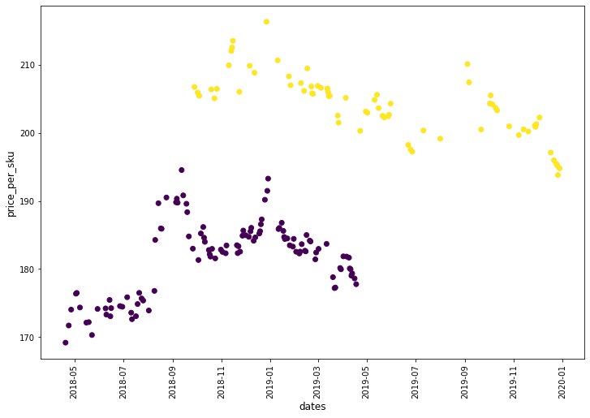

```python
plt.figure(figsize=(12, 8))
plt.scatter(x='dates', y='price_per_sku', data=ZX10208_df, c='SKU')
plt.ylabel('price_per_sku', fontsize=12)
plt.xlabel('dates', fontsize=12)
plt.xticks(rotation='vertical')
plt.show()
```

Добавим в датасет новые временные features, такие как год (`year`), месяц (`month`), номер недели (`week_num`) и комбинацию год-неделя (`year_week`) и снова посмотрим на результат

```python
# week month and year
ZX10208_df['week_num'] = ZX10208_df.dates.dt.week
ZX10208_df['year'] = ZX10208_df.dates.dt.year
ZX10208_df['months'] = ZX10208_df.dates.dt.month
ZX10208_df['year_week'] =  ZX10208_df['year'].astype(str) + '_' + ZX10208_df['week_num'].astype(str)
```

```python
ZX10208_df.head()
```

|  | dates | SKU | price_per_sku | num_purchases | week_num | year | months | year_week |
| --- | --- | --- | --- | --- | --- | --- | --- | --- |
| 0 | 2018-04-20 | 59567 | 169.19 | 3 | 16 | 2018 | 4 | 2018_16 |
| 1 | 2018-04-24 | 59567 | 171.71 | 3 | 17 | 2018 | 4 | 2018_17 |
| 2 | 2018-04-27 | 59567 | 174.04 | 3 | 17 | 2018 | 4 | 2018_17 |
| 3 | 2018-04-30 | 59567 | NaN | 1 | 18 | 2018 | 4 | 2018_18 |
| 4 | 2018-05-03 | 59567 | 176.38 | 2 | 18 | 2018 | 5 | 2018_18 |

Теперь давайте посчитаем среднее значение стоимости `SKU` в неделю. Обратим внимание, что группировка идет по переменной `year_week`, а не `week_num`, потому что мы хотим отличать недели в разных годах. Также переименуем для удобства полученную переменную как `mean_per_week` и присоединим к оригинальному датасету. В анализе данных подсчет средних и медианных значений нередко помогает уменьшить влияние выбросов (outlier'ов) и увидеть присутствующие тренды

```python
ZX10208_gr = ZX10208_df.groupby(['year_week','SKU']).price_per_sku.mean().reset_index()
```

```python
ZX10208_gr = ZX10208_gr.rename(columns={'price_per_sku': 'mean_per_week'})
```

```python
ZX10208_df = ZX10208_df.merge(ZX10208_gr, how='left', on=['year_week','SKU'])
```

```python
ZX10208_df
```

|  | dates | SKU | price_per_sku | num_purchases | week_num | year | months | year_week | mean_per_week |
| --- | --- | --- | --- | --- | --- | --- | --- | --- | --- |
| 0 | 2018-04-20 | 59567 | 169.19 | 3 | 16 | 2018 | 4 | 2018_16 | 169.190 |
| 1 | 2018-04-24 | 59567 | 171.71 | 3 | 17 | 2018 | 4 | 2018_17 | 172.875 |
| 2 | 2018-04-27 | 59567 | 174.04 | 3 | 17 | 2018 | 4 | 2018_17 | 172.875 |
| 3 | 2018-04-30 | 59567 | NaN | 1 | 18 | 2018 | 4 | 2018_18 | 176.435 |
| 4 | 2018-05-03 | 59567 | 176.38 | 2 | 18 | 2018 | 5 | 2018_18 | 176.435 |
| ... | ... | ... | ... | ... | ... | ... | ... | ... | ... |
| 254 | 2019-12-23 | 82947 | NaN | 1 | 52 | 2019 | 12 | 2019_52 | 194.810 |
| 255 | 2019-12-24 | 82947 | 195.46 | 2 | 52 | 2019 | 12 | 2019_52 | 194.810 |
| 256 | 2019-12-25 | 82947 | 195.21 | 1 | 52 | 2019 | 12 | 2019_52 | 194.810 |
| 257 | 2019-12-26 | 82947 | 193.79 | 1 | 52 | 2019 | 12 | 2019_52 | 194.810 |
| 258 | 2019-12-28 | 82947 | 194.78 | 1 | 52 | 2019 | 12 | 2019_52 | 194.810 |

259 rows × 9 columns

Визуализируем среднюю стоимость `SKU` за неделю от собственно номера недели для значения `SKU = 59567`

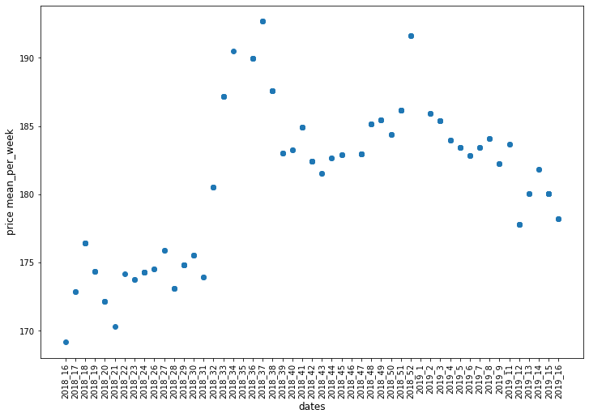

```python
plt.figure(figsize=(12, 8))
plt.scatter(x='year_week', y='mean_per_week',
            data=ZX10208_df[ZX10208_df.SKU == 59567].sort_values('dates'))
plt.ylabel('price mean_per_week', fontsize=12)
plt.xlabel('dates', fontsize=12)
plt.xticks(rotation='vertical')
plt.show()
```

Теперь хотелось бы построить график среднего значения `SKU` в зависимости от даты для всех (в нашем случае 2х) значений `SKU`. Для этого будет удобно несколько переоформатировать наш `DataFrame` с помощью метода `pivot_table()`. Он построит таблицу зависимости всех значений параметра `values` от значений параметра `index` для каждого из уникальных значений параметра из `columns` . Получится следующее:

```python
pivot_t = ZX10208_df.pivot_table(index='dates', columns='SKU', values='price_per_sku')
```

```python
pivot_t
```

| SKU dates | 59567 | 82947 |
| --- | --- | --- |
| 2018-04-20 | 169.19 | NaN |
| 2018-04-24 | 171.71 | NaN |
| 2018-04-27 | 174.04 | NaN |
| 2018-05-03 | 176.38 | NaN |
| 2018-05-04 | 176.49 | NaN |
| ... | ... | ... |
| 2019-12-21 | NaN | 195.96 |
| 2019-12-24 | NaN | 195.46 |
| 2019-12-25 | NaN | 195.21 |
| 2019-12-26 | NaN | 193.79 |
| 2019-12-28 | NaN | 194.78 |

181 rows × 2 columns

И теперь ее легко построить

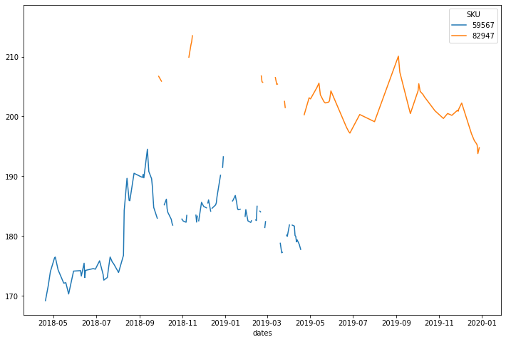

```python
plt.figure(figsize=(12, 8))
sns.lineplot(data=pivot_t, dashes=False)
```

Мы видим, что цены сильно меняются по дням, причем в районе августа 2018 года цена `SKU=59567` сильно выросла, а потом снвоа упала. Через некоторое время произощел еще один скачек в районе января 2019 года. С ценой другого `SKU` происходтя похожие осцилляции, но с видимым нисходящим трендом

# 1510001 group

Считаем данные по этой группе и, как обычно, посмотрим на структуру файла

```python
df_1510001 = pd.read_csv('1510001_agr.csv')
```

```python
df_1510001
```

|  | dates | SKU | price_per_sku | num_purchases |
| --- | --- | --- | --- | --- |
| 0 | 2018-08-02 | 39665 | 85.940 | 1 |
| 1 | 2018-08-03 | 39665 | 85.940 | 1 |
| 2 | 2018-08-04 | 39665 | 85.940 | 1 |
| 3 | 2018-08-05 | 39665 | 85.940 | 1 |
| 4 | 2018-08-06 | 39665 | 86.038 | 1 |
| ... | ... | ... | ... | ... |
| 3935 | 2019-12-25 | 36108 | 80.094 | 2 |
| 3936 | 2019-12-28 | 36108 | 80.094 | 2 |
| 3937 | 2019-12-29 | 36108 | 80.094 | 1 |
| 3938 | 2019-12-30 | 36108 | 76.205 | 1 |
| 3939 | 2019-12-31 | 36108 | 76.205 | 1 |

3940 rows × 4 columns

Видим знакомую уже нам структуру. `SKU`, даты, цену и количество покупок. Видим, что цена не сильно меняется со временем. Снова, как и в предыдщуем примере, построим "широкую" таблицу зависимости цен от времени для каждого `SKU`

```python
df_1510001.dates = pd.to_datetime(df_1510001.dates)
```

```python
pivot_t = df_1510001.pivot_table(index='dates', columns='SKU', values='price_per_sku')
```

```python
pivot_t
```

| SKU dates | 27240 | 27885 | 34130 | 36108 | 39665 | 40194 | 45164 | 48671 | 49596 | 59631 | 63995 | 70252 | 70315 | 72449 |
| --- | --- | --- | --- | --- | --- | --- | --- | --- | --- | --- | --- | --- | --- | --- |
| 2018-03-02 | NaN | NaN | NaN | NaN | NaN | NaN | NaN | NaN | NaN | NaN | NaN | 107.784 | NaN | NaN |
| 2018-03-03 | NaN | NaN | NaN | NaN | NaN | NaN | NaN | NaN | NaN | NaN | NaN | 107.784 | NaN | NaN |
| 2018-03-04 | NaN | NaN | NaN | NaN | NaN | NaN | NaN | NaN | NaN | NaN | NaN | 107.784 | NaN | NaN |
| 2018-03-05 | NaN | NaN | NaN | NaN | NaN | NaN | NaN | NaN | NaN | NaN | NaN | 107.882 | NaN | NaN |
| 2018-03-06 | NaN | NaN | NaN | NaN | NaN | NaN | NaN | NaN | NaN | NaN | NaN | 107.882 | NaN | NaN |
| ... | ... | ... | ... | ... | ... | ... | ... | ... | ... | ... | ... | ... | ... | ... |
| 2019-12-27 | 128.652 | NaN | 104.536 | NaN | 95.978 | 135.931 | 82.652 | 152.815 | 148.536 | NaN | 138.536 | NaN | 71.931 | 156.257 |
| 2019-12-28 | NaN | NaN | NaN | 80.094 | 95.978 | NaN | 82.652 | 152.815 | NaN | 108.536 | 138.536 | 117.815 | 71.931 | 156.257 |
| 2019-12-29 | 128.652 | NaN | 104.536 | 80.094 | 95.978 | 135.931 | 82.652 | NaN | 148.536 | NaN | 138.536 | NaN | 71.931 | 156.257 |
| 2019-12-30 | NaN | NaN | NaN | 76.205 | 87.015 | 133.475 | 79.840 | 148.205 | NaN | NaN | 132.110 | NaN | 68.015 | NaN |
| 2019-12-31 | NaN | NaN | 98.840 | 76.205 | 87.015 | 133.475 | NaN | 148.205 | 142.475 | NaN | 132.110 | 112.475 | 68.015 | 149.110 |

650 rows × 14 columns

И визуализируем эти динамики цен

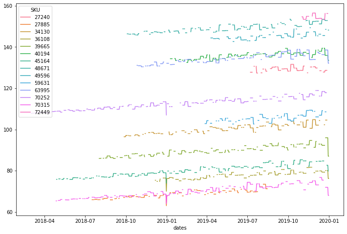

```python
plt.figure(figsize=(12, 8))
sns.lineplot(data=pivot_t, dashes=False)
```

На графике можно увидеть, что цены на кадый из `SKU` медленно растет

Давайте посмотрим на колчество уникальных значений `SKU` и собственно на сами значения

```python
df_1510001.SKU.nunique()
```

```
14
```

```python
df_1510001.SKU.unique()
```

```
array([39665, 63995, 70252, 34130, 70315, 27885, 59631, 48671, 72449,
       49596, 27240, 45164, 40194, 36108], dtype=int64)
```

Также можно посмотреть статистики для какого-нибудь конкретного значения `SKU`, например для `SKU = 39665`

```python
df_1510001[df_1510001.SKU == 39665].num_purchases.describe()
```

```
count    354.000000
mean       1.519774
std        0.694702
min        1.000000
25%        1.000000
50%        1.000000
75%        2.000000
max        3.000000
Name: num_purchases, dtype: float64
```

Теперь давайте визуализируем кривую **эластичности спроса** (зависимость цены $P$ от колчество сбыта $Q$)

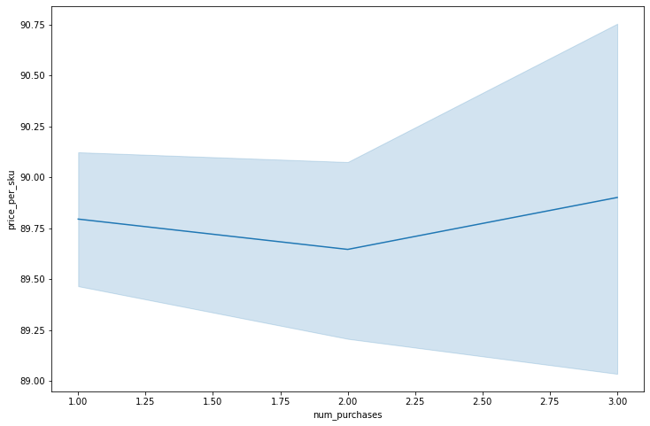

```python
plt.figure(figsize=(12, 8))
sns.lineplot(x=df_1510001[df_1510001.SKU == 39665].num_purchases,
             y=df_1510001[df_1510001.SKU == 39665].price_per_sku)
```

Судя по графику, сложно сказать, к какой динамике сбыта `SKU` приведет изменение (понижение) цены (слишком широкий интервал)

# 1510002 group

Рассмотри теперь еще несколько групп. В них соответствующие тренды видны куда сильнее

Снова загрузим файлы

```python
df_1510002 = pd.read_csv('1510002_agr.csv')
```

```python
df_1510002.dates = pd.to_datetime(df_1510002.dates)
```

Совершенно аналогично сгенерируем "широкую" таблицу с помощью `pivot_table()`

```python
pivot_t = df_1510002.pivot_table(index='dates', columns='SKU', values='price_per_sku')
```

```python
pivot_t
```

| SKU dates | 10334 | 17812 | 36096 | 38767 | 43678 | 57561 | 64619 | 68211 | 69997 | 72784 | 83329 | 90611 | 98255 |
| --- | --- | --- | --- | --- | --- | --- | --- | --- | --- | --- | --- | --- | --- |
| 2018-01-24 | NaN | NaN | NaN | NaN | NaN | NaN | NaN | NaN | NaN | 124.294 | NaN | NaN | NaN |
| 2018-01-25 | NaN | NaN | NaN | NaN | NaN | NaN | NaN | NaN | NaN | 124.294 | NaN | NaN | NaN |
| 2018-01-27 | NaN | NaN | NaN | NaN | NaN | NaN | NaN | NaN | NaN | 124.294 | NaN | NaN | NaN |
| 2018-01-28 | NaN | NaN | NaN | NaN | NaN | NaN | NaN | NaN | NaN | 124.294 | NaN | NaN | NaN |
| 2018-01-29 | NaN | NaN | NaN | NaN | NaN | NaN | NaN | NaN | NaN | 124.420 | NaN | NaN | NaN |
| ... | ... | ... | ... | ... | ... | ... | ... | ... | ... | ... | ... | ... | ... |
| 2019-12-27 | 101.094 | 77.373 | 119.3868 | NaN | 148.373 | NaN | 150.652 | NaN | NaN | 132.652 | 88.815 | NaN | NaN |
| 2019-12-28 | 101.094 | 77.373 | 119.3868 | 74.536 | 148.373 | NaN | NaN | NaN | NaN | NaN | NaN | 97.699 | NaN |
| 2019-12-29 | 101.094 | NaN | 119.3868 | 74.536 | NaN | NaN | 150.652 | NaN | NaN | NaN | 88.815 | 97.699 | NaN |
| 2019-12-30 | 96.475 | 72.745 | NaN | 67.745 | 143.380 | NaN | NaN | NaN | NaN | NaN | NaN | NaN | NaN |
| 2019-12-31 | 96.475 | 72.745 | NaN | 67.745 | 143.380 | NaN | NaN | NaN | NaN | NaN | 82.745 | 79.542 | NaN |

702 rows × 13 columns

И визуализируем (как и раньше)

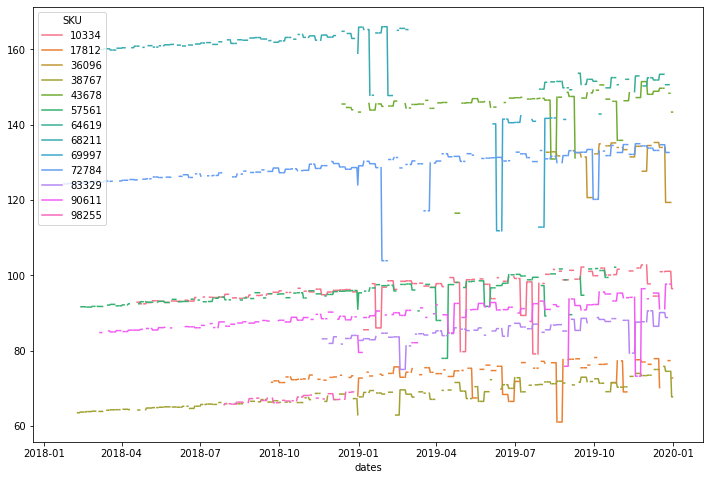

```python
plt.figure(figsize=(12, 8))
sns.lineplot(data=pivot_t, dashes=False)
```

Пока по графику не очень понятно, что происходит (очень сильные осцилляции)

Загрузим `DataFrame` с информацией по промоакциям (`discount` - скидка на товар). Необходимо помнить, что в данном случае цена на `SKU` уже с учетом скидки

```python
promo_df = pd.read_csv('promo_1510002.csv')
```

```python
promo_df.discount = 1 - promo_df.discount
```

Как обычно уже дополним наши данные годом (`year`) и номером недели (`num_week`) и посмотрим что будет происходить количеством покупок, начиная с 1 января 2019 для `SKU` 72784

```python
df_1510002['year'] = df_1510002.dates.dt.year
df_1510002['week_num'] = df_1510002.dates.dt.week
df_1510002 = df_1510002[df_1510002.dates >= pd.to_datetime('2019-01-01')]
```

```python
df_72784 = df_1510002[df_1510002.SKU == 72784]
```

Посмотрим на максимальное значение продаж на каждой неделе

```python
df_72784.groupby(['year', 'week_num']).num_purchases.max().reset_index()
```

|  | year | week_num | num_purchases |
| --- | --- | --- | --- |
| 0 | 2019 | 1 | 8 |
| 1 | 2019 | 2 | 7 |
| 2 | 2019 | 3 | 7 |
| 3 | 2019 | 4 | 7 |
| 4 | 2019 | 5 | 11 |
| 5 | 2019 | 6 | 6 |
| 6 | 2019 | 7 | 6 |
| 7 | 2019 | 8 | 8 |
| 8 | 2019 | 9 | 8 |
| 9 | 2019 | 10 | 8 |
| 10 | 2019 | 11 | 8 |
| 11 | 2019 | 12 | 10 |
| 12 | 2019 | 13 | 6 |
| 13 | 2019 | 14 | 7 |
| 14 | 2019 | 15 | 6 |
| 15 | 2019 | 16 | 7 |
| 16 | 2019 | 17 | 8 |
| 17 | 2019 | 18 | 7 |
| 18 | 2019 | 19 | 6 |
| 19 | 2019 | 20 | 6 |
| 20 | 2019 | 21 | 8 |
| 21 | 2019 | 22 | 7 |
| 22 | 2019 | 23 | 8 |
| 23 | 2019 | 24 | 7 |
| 24 | 2019 | 25 | 8 |
| 25 | 2019 | 26 | 7 |
| 26 | 2019 | 27 | 7 |
| 27 | 2019 | 28 | 7 |
| 28 | 2019 | 29 | 6 |
| 29 | 2019 | 30 | 8 |
| 30 | 2019 | 31 | 6 |
| 31 | 2019 | 32 | 8 |
| 32 | 2019 | 33 | 8 |
| 33 | 2019 | 34 | 7 |
| 34 | 2019 | 35 | 7 |
| 35 | 2019 | 36 | 8 |
| 36 | 2019 | 37 | 8 |
| 37 | 2019 | 38 | 8 |
| 38 | 2019 | 39 | 7 |
| 39 | 2019 | 40 | 10 |
| 40 | 2019 | 41 | 8 |
| 41 | 2019 | 42 | 8 |
| 42 | 2019 | 43 | 6 |
| 43 | 2019 | 44 | 7 |
| 44 | 2019 | 45 | 8 |
| 45 | 2019 | 46 | 8 |
| 46 | 2019 | 47 | 8 |
| 47 | 2019 | 48 | 7 |
| 48 | 2019 | 49 | 8 |
| 49 | 2019 | 50 | 7 |
| 50 | 2019 | 51 | 6 |
| 51 | 2019 | 52 | 7 |

Совместим данные про промоакции с основными данными и добавим изначальную цену до учета скидок

```python
df_1510002 = df_1510002.merge(promo_df, how='left', on=['SKU', 'year', 'week_num'])
```

```python
df_1510002['real_price_per_sku'] = df_1510002.price_per_sku / (1 - df_1510002.discount)
```

```python
df_1510002[~df_1510002.discount.isnull()]
```

|  | dates | SKU | price_per_sku | num_purchases | year | week_num | discount | real_price_per_sku |
| --- | --- | --- | --- | --- | --- | --- | --- | --- |
| 0 | 2019-01-01 | 90611 | 79.5420 | 7 | 2019 | 1 | 0.1 | 88.380 |
| 13 | 2019-01-02 | 90611 | 79.5420 | 7 | 2019 | 1 | 0.1 | 88.380 |
| 20 | 2019-01-03 | 90611 | 79.5420 | 9 | 2019 | 1 | 0.1 | 88.380 |
| 27 | 2019-01-04 | 90611 | 79.5420 | 6 | 2019 | 1 | 0.1 | 88.380 |
| 35 | 2019-01-05 | 90611 | 79.5420 | 6 | 2019 | 1 | 0.1 | 88.380 |
| ... | ... | ... | ... | ... | ... | ... | ... | ... |
| 2285 | 2019-12-26 | 36096 | 119.3868 | 14 | 2019 | 52 | 0.1 | 132.652 |
| 2298 | 2019-12-27 | 36096 | 119.3868 | 13 | 2019 | 52 | 0.1 | 132.652 |
| 2299 | 2019-12-28 | 36096 | 119.3868 | 13 | 2019 | 52 | 0.1 | 132.652 |
| 2305 | 2019-12-29 | 36096 | 119.3868 | 14 | 2019 | 52 | 0.1 | 132.652 |
| 2315 | 2019-12-31 | 90611 | 79.5420 | 6 | 2019 | 1 | 0.1 | 88.380 |

281 rows × 8 columns

# 1510003 group

Теперь посмотрим на финальную группу. Как обычно считаем данные и посмотрим на структуру файлов

Тут в файле `conc_df.csv` содержатся данные про цены у конкурентов

```python
df_1 = pd.read_csv('1510003_agr.csv')
```

```python
df_1
```

|  | dates | SKU | price_per_sku | num_purchases |
| --- | --- | --- | --- | --- |
| 0 | 2018-11-17 | 54404 | 80.095 | 11 |
| 1 | 2018-11-18 | 54404 | 80.095 | 12 |
| 2 | 2018-11-19 | 54404 | 81.796 | 10 |
| 3 | 2018-11-20 | 54404 | 81.796 | 11 |
| 4 | 2018-11-21 | 54404 | 81.796 | 10 |
| ... | ... | ... | ... | ... |
| 2846 | 2019-12-27 | 49661 | 165.978 | 10 |
| 2847 | 2019-12-28 | 49661 | 165.978 | 9 |
| 2848 | 2019-12-29 | 49661 | 165.978 | 10 |
| 2849 | 2019-12-30 | 49661 | 159.205 | 8 |
| 2850 | 2019-12-31 | 49661 | 159.205 | 8 |

2851 rows × 4 columns

```python
conc_df = pd.read_csv('conc_df.csv')
```

```python
conc_df
```

|  | SKU | year | week_num | ret_net_code | price_per_sku |
| --- | --- | --- | --- | --- | --- |
| 0 | 84395 | 2019 | 18 | 1 | 164.69400 |
| 1 | 84395 | 2019 | 18 | 2 | 164.69400 |
| 2 | 84395 | 2019 | 18 | 3 | 134.50010 |
| 3 | 84395 | 2019 | 22 | 1 | 165.19800 |
| 4 | 84395 | 2019 | 22 | 2 | 136.28835 |
| ... | ... | ... | ... | ... | ... |
| 3004 | 89272 | 2019 | 18 | 2 | 133.93820 |
| 3005 | 89272 | 2019 | 18 | 3 | 121.76200 |
| 3006 | 80308 | 2019 | 47 | 1 | 115.77984 |
| 3007 | 80308 | 2019 | 47 | 2 | 118.19192 |
| 3008 | 80308 | 2019 | 47 | 3 | 116.98588 |

3009 rows × 5 columns

Посмотрим на цены тех товаров, что торгуются и у конкурентов

```python
df_1[df_1.SKU.isin(conc_df.SKU.unique())]
```

|  | dates | SKU | price_per_sku | num_purchases |
| --- | --- | --- | --- | --- |
| 0 | 2018-11-17 | 54404 | 80.095 | 11 |
| 1 | 2018-11-18 | 54404 | 80.095 | 12 |
| 2 | 2018-11-19 | 54404 | 81.796 | 10 |
| 3 | 2018-11-20 | 54404 | 81.796 | 11 |
| 4 | 2018-11-21 | 54404 | 81.796 | 10 |
| ... | ... | ... | ... | ... |
| 2846 | 2019-12-27 | 49661 | 165.978 | 10 |
| 2847 | 2019-12-28 | 49661 | 165.978 | 9 |
| 2848 | 2019-12-29 | 49661 | 165.978 | 10 |
| 2849 | 2019-12-30 | 49661 | 159.205 | 8 |
| 2850 | 2019-12-31 | 49661 | 159.205 | 8 |

2851 rows × 4 columns

Как обычно приведем формат временных данных в удобный и добавим новые features - неделю (`week_num`) и год (`year`)

```python
df_1.dates = pd.to_datetime(df_1.dates)
```

```python
df_1['year'] = df_1.dates.dt.year
df_1['week_num'] = df_1.dates.dt.week
```

Посмотрим предельные цены на каждый из товаров *у конкурентов* на каждой неделе и присоединим полученную информацию к исходным данным

```python
conc_aggr = conc_df.groupby(['SKU', 'year', 'week_num']).price_per_sku.agg(['min', 'max']).reset_index()
```

```python
df_1 = df_1.merge(conc_aggr, how='left', on=['SKU', 'year', 'week_num'])
```

Внимательней изучим полученный результат для конкретного `SKU` (например, для 80308)

```python
df_80308 = df_1[df_1.SKU == 80308]
```

```python
df_80308
```

|  | dates | SKU | price_per_sku | num_purchases | year | week_num | min | max |
| --- | --- | --- | --- | --- | --- | --- | --- | --- |
| 853 | 2018-07-17 | 80308 | 113.940 | 8 | 2018 | 29 | NaN | NaN |
| 854 | 2018-07-18 | 80308 | 113.940 | 8 | 2018 | 29 | NaN | NaN |
| 855 | 2018-07-20 | 80308 | 113.940 | 8 | 2018 | 29 | NaN | NaN |
| 856 | 2018-07-21 | 80308 | 113.940 | 7 | 2018 | 29 | NaN | NaN |
| 857 | 2018-07-22 | 80308 | 113.940 | 8 | 2018 | 29 | NaN | NaN |
| ... | ... | ... | ... | ... | ... | ... | ... | ... |
| 1235 | 2019-12-27 | 80308 | 122.536 | 10 | 2019 | 52 | 122.536 | 147.0432 |
| 1236 | 2019-12-28 | 80308 | 122.536 | 9 | 2019 | 52 | 122.536 | 147.0432 |
| 1237 | 2019-12-29 | 80308 | 122.536 | 9 | 2019 | 52 | 122.536 | 147.0432 |
| 1238 | 2019-12-30 | 80308 | 116.475 | 7 | 2019 | 1 | 111.816 | 128.1225 |
| 1239 | 2019-12-31 | 80308 | 116.475 | 5 | 2019 | 1 | 111.816 | 128.1225 |

387 rows × 8 columns

Построим график количества покупок в зависимости от цен у конкурентов

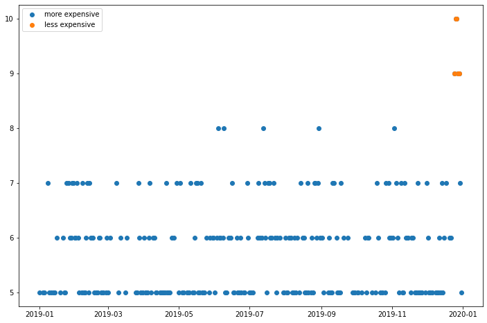

```python
plt.figure(figsize=(12, 8))
plt.scatter(x=df_80308[df_80308.price_per_sku >= df_80308['min']].dates,
            y=df_80308[df_80308.price_per_sku >= df_80308['min']].num_purchases,
            label='more expensive')
plt.scatter(x=df_80308[df_80308.price_per_sku <= df_80308['min']].dates,
            y=df_80308[df_80308.price_per_sku <= df_80308['min']].num_purchases,
            label='less expensive')
plt.legend()
```

Из графика видно, что когда цена на товар выше, чем у конкурентов, то продажи держатся на уровен 5-8 товаров в день/неделю, а когда же цена на товар выгодней, чем у конкурентов, то прожади взлетают до 9+ товаров за период